# Poisson and Exponential Distributions

XDASI Fall 2021

10/21/2021

# Background

- **W&S Chapter 8.4**
- [**Aho - Chapter 3.3-3.6**](https://drive.google.com/file/d/1cjF3ykw5K1_gjd4mydDN9fvBdzELpLvk/view?usp=sharing)

# Poisson Distribution

The Poisson is a *discrete* distribution that describes the probability of observing a certain number of events in a given interval of time (or space), if the events occur *randomly* and *independently* of each other. It is used to model stochastic processes, such as shot noise or scattered objects.

The Poisson is actually a **limiting case of the binomial** when $n$ is large and $p$ is small, and it is particularly useful for *rare* events. We will talk about this more below.

Examples in *time*:

- The number of gamma rays detected in a scintillation counter over time (the number of particles emitted over time due to exponential decay)
- The number of mutations that accumulate per generation in biological systems
- The number of accidents in New York City per day
- The number of coffee orders per minute at the Matto coffee shop on Mercer

Examples in *space*:

- The number of mutations per kilobase after treatment with a mutagen (e.g. EMS)
- Distribution of bacterial colonies on an evenly spread agar plate, or of bacteriophage plaques plated at low multiplicity
- Distribution of gas molecules in a closed container
- The number of typos per page in a book
- Distribution of chocolate chips in cookie dough

Any process that gives rise to events that are randomly distributed in space or time, where events happen at a constant rate and the number of occurrences in non-overlapping intervals is statistically independent, is called a **Poisson process**.

## Visualization

The Poisson has a single parameter, $\lambda$, which is called the *rate constant*. Lambda is the *expected number of events per unit time $t$*. The figure and code below show how the shape of the PDF and CDF change with increasing $\lambda$.

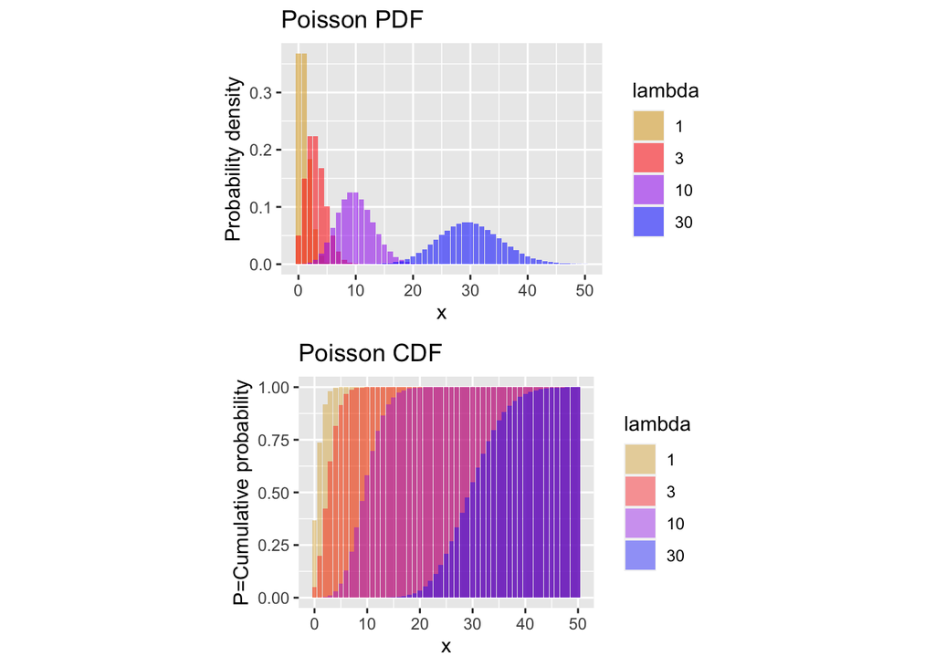

```r
x=c(0:50)
pois.dist = data.frame(x = x,
                       l1 = dpois(x, 1),
                       l3 = dpois(x, 3),
                       l10 = dpois(x, 10),
                       l30 = dpois(x, 30))
pois.dist.long = gather(pois.dist, "lambda", "density", 2:5)
pois.dist.long = pois.dist.long %>% mutate(lambda = substring(lambda,2))
pois.dist.long = pois.dist.long %>% mutate(lambda = factor(lambda, c(1,3,10,30)))

p.pdf = ggplot(pois.dist.long, aes(x=x)) +
  geom_bar(aes(y=density, fill=lambda), alpha=0.54,
           stat="identity", position="identity") +
  scale_fill_manual(values = c("goldenrod","red","purple","blue")) +
  ylab("Probability density") +
  ggtitle("Poisson PDF") +
  coord_fixed(ratio = 100)

pois.cum = data.frame(x = x,
                       l1 = ppois(x, 1),
                       l3 = ppois(x, 3),
                       l10 = ppois(x, 10),
                       l30 = ppois(x, 30))
pois.cum.long = gather(pois.cum, "lambda", "density", 2:5)
pois.cum.long = pois.cum.long %>% mutate(lambda = substring(lambda,2))
pois.cum.long = pois.cum.long %>% mutate(lambda = factor(lambda, c(1,3,10,30)))

p.cdf = ggplot(pois.cum.long, aes(x=x)) +
  geom_bar(aes(y=density, fill=lambda), alpha=0.4,
           stat="identity", position="identity") +
  scale_fill_manual(values = c("goldenrod","red","purple","blue")) +
  ylab("P=Cumulative probability") +
  ggtitle("Poisson CDF") +
  coord_fixed(ratio = 40)

ggarrange(p.pdf, p.cdf, nrow=2, ncol=1)
```

The PDF shows the *probability seeing $x$ events in one unit of time*. When events are rare, the rate constant $\lambda$ is small and it is very unlikely that we will see a lot of events per unit time, so the distribution is squished to the left (a.k.a. “right-skewed”). When $\lambda$ is large, that means that events are much more frequent, so it’s much more likely we will see lots of events per unit time.

We can see from the PDF that the distribution starts to look a lot like a normal distribution as $\lambda$ gets bigger.